# Data Import and Cleanup (study2children)

Adam Stone, PhD

04-20-2018

# Introduction

```r
# Libraries
library(tidyverse)
library(feather)
library(stringr)
#library(cowplot)
# Import data. If you're adding any new participants you need to run the first code block in
# 01importclean.Rmd which will add those to the .feather file. And add the age to childrenages.csv.
data <- read_feather("childrawdata.feather")
# Get ages
ages <- read_csv("childrenages.csv")
data <- data %>% left_join(ages, by = "participant")
data %>% select(participant,language,age) %>% distinct() # print data table
```

| participant | language | age |
| --- | --- | --- |
| Ab07ov09_32m | EnglishExposed | 2.70 |
| AB11Mi20_5M_10D | EnglishExposed | 0.40 |
| Ainsely03_27_5y_1m | EnglishExposed | 5.10 |
| al10pa24_4yrs | EnglishExposed | 4.00 |
| Allan_SE_3.5y | SignLanguageExposed | 3.50 |
| an06he01_6m | EnglishExposed | 0.50 |
| Annika_3_24_10_CODA | SignLanguageExposed | 6.00 |
| AsherCalibOnly | EnglishExposed | 0.00 |
| aubrey CODA 11m | SignLanguageExposed | 0.90 |
| Aveline CODA 6y,1m | SignLanguageExposed | 5.10 |

[output cut: 71 more lines]

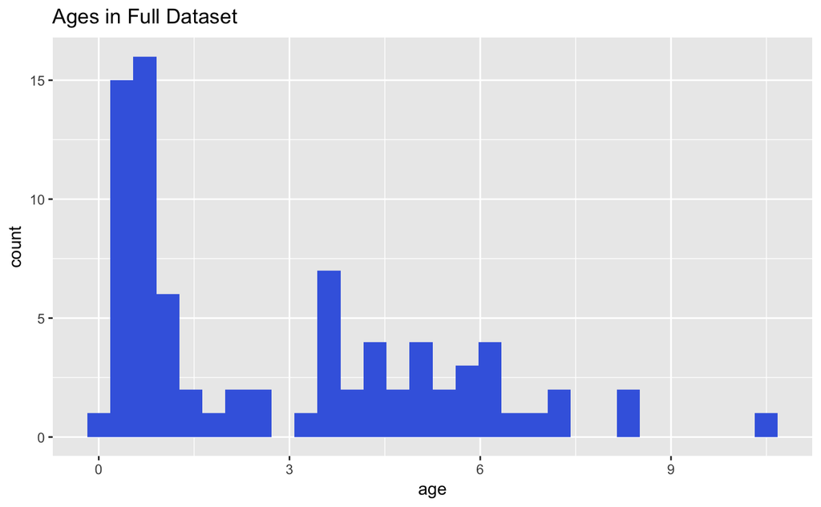

```r
# Histogram of ages
data %>% select(participant,language,age) %>%
  distinct() %>%
  ggplot(aes(x = age)) + geom_histogram(fill = "royalblue") + ggtitle("Ages in Full Dataset")
```

# Removing Bad/Irrelevant Data

First, let’s get rid of all below 2 years old (those are babies and are dealt with later). Then we’re going to remove specific children for various reasons, here’s a list of who we removed.

```r
alldata <- data
data <- data %>%
  filter(age > 2.0) %>%
  filter(participant != "Kiera_8_20_13 3y,5m") %>%
  filter(participant != "Isabella 5 year old Deaf")
anti_join(alldata, data, by = "participant") %>%
  select(participant, recording, analysis, language, group, age) %>%
  distinct() %>%
  filter(age > 2.0)
```

| participant | recording | analysis | language | group | age |
| --- | --- | --- | --- | --- | --- |
| Isabella 5 year old Deaf | Isabella 5 year old DEAF recently exposed to sign | GoodData | SignLanguageExposed | 2 | 5.0 |
| Kiera_8_20_13 3y,5m | Rec 08 little SHRUNKEN | Good_But_Needs_Shift | EnglishExposed | 1 | 3.4 |

All children saw all trials. Now, we need to remove trials where looking data was collected <25% of the video length. I’m importing a table of clip lengths, see below. The videos were shown at 25 FPS so frames / 25 = seconds.

```r
cliplength <- read_csv("cliplengths.csv") %>%
  rename(clip_sec = seconds) %>%
  separate(story, into = c("video", "clipnum")) %>%
  filter(clipnum < 3) %>%
  unite(video, clipnum, col = "story", sep = "_")
cliplength
```

| story | frames | clip_sec |
| --- | --- | --- |
| Cinderella_1 | 211 | 8.44 |
| Cinderella_2 | 105 | 4.20 |
| KingMidas_1 | 228 | 9.12 |
| KingMidas_2 | 277 | 11.08 |
| RedRiding_1 | 210 | 8.40 |
| RedRiding_2 | 193 | 7.72 |
| ThreeBears_1 | 188 | 7.52 |
| ThreeBears_2 | 278 | 11.12 |

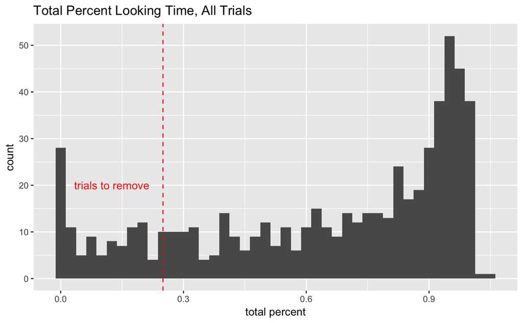

```r
trialcheck <- data %>%
  group_by(participant, condition, trial) %>%
  summarise(hits = sum(hits)) %>%
  mutate(secs = hits/120) %>%
  separate(condition, into = c("story", "clipnum", "direction", "media"), sep = "_") %>%
  unite(story, clipnum, col = "story", sep = "_") %>%
  left_join(cliplength, by = "story") %>%
  mutate(percent = secs / clip_sec) %>%
  mutate(lessthan25 = percent <= 0.25)
# Histogram of trial total percentages
ggplot(trialcheck, aes(x = percent)) +
  geom_histogram(binwidth = 0.025) + ggtitle("Total Percent Looking Time, All Trials") + xlab("total percent") +
  geom_vline(xintercept = 0.25, linetype = "dashed", color = "red") +
  annotate("text", x = 0.125, y = 20, label = "trials to remove", color = "red")
```

```r
# Values to put in commentary
numtotakeout = sum(trialcheck$lessthan25)
numtotaltrials = dim(trialcheck)[1]
percenttakeout = paste(numtotakeout/numtotaltrials * 100, "%", sep = "")
```

We removed 106 trials out of 501 (21.1576846307385%). Was there any correlation with the number of trials removed by age, language, or gender? Scatterplot below - looks fine. (Took out one CODA girl that has nearly all trials removed, was skewing the data).

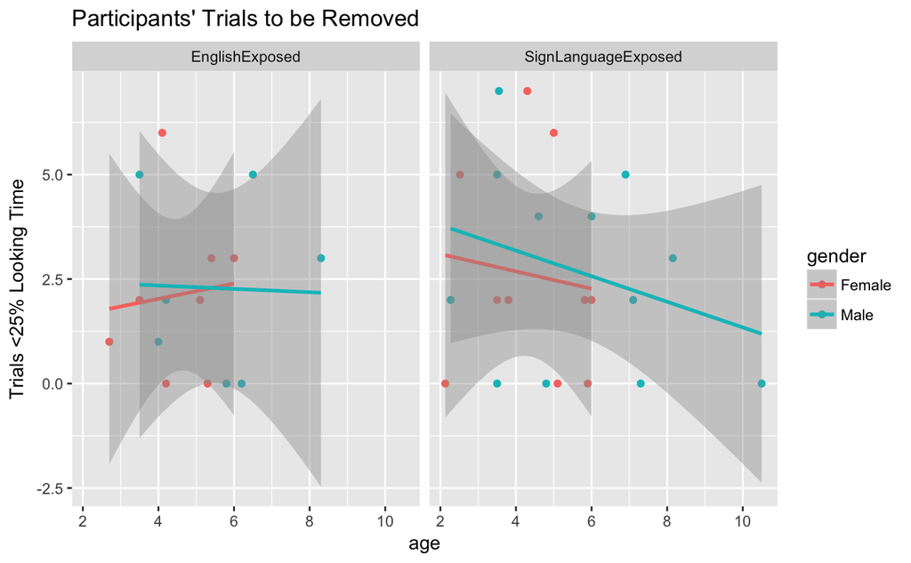

```r
# Grab age/group data we need for scatterplot
agegroup <- data %>%
  select(participant, age, language, gender) %>%
  distinct()
# Join age/group data with trialcheck data (actually trialcheck2, just for plotting)
trialcheck2 <- trialcheck %>%
  group_by(participant) %>%
  summarize(trialsremoved = sum(lessthan25)) %>%
  left_join(agegroup, by = "participant") %>%
  filter(trialsremoved < 10)
# Scatterplot of bad trials grouped by age, language, gender
ggplot(trialcheck2, aes(x = age, y = trialsremoved, color = gender)) + geom_point() +
  facet_wrap("language") + geom_smooth(method = "lm") +
  ggtitle("Participants' Trials to be Removed") + ylab("Trials <25% Looking Time")
```

```r
NA
```

Now take out bad trials - and let’s check how many good trials each child has.

```r
# Select only bad trials to use in an anti_join
trialcheck <- trialcheck %>%
  filter(lessthan25 == TRUE) %>%
  select(participant, trial)
# Now remove all bad trials.
data <- data %>%
  anti_join(trialcheck, by = c("participant","trial"))
# Table of trials per baby
data %>% select(participant, language, trial) %>% distinct() %>% group_by(language, participant) %>% summarise(trials = n()) %>% arrange(trials)
```

| language | participant | trials |
| --- | --- | --- |
| SignLanguageExposed | JelenaCODAhearing_4y2m | 2 |
| SignLanguageExposed | Gianni 3y6m CODA | 6 |
| SignLanguageExposed | sophia | 9 |
| EnglishExposed | Elizabeth 11_17_11_4y1m | 10 |
| SignLanguageExposed | JuliaCoda | 10 |
| EnglishExposed | na01pe06_2013_3.5y | 11 |
| EnglishExposed | Timothy_7_18_09_6.5y | 11 |
| SignLanguageExposed | Cyrus_SE_3.5y | 11 |
| SignLanguageExposed | Gavin | 11 |
| SignLanguageExposed | GiaLessa 2y2m CODA | 11 |

[output cut: 28 more lines]

So based on that, we’re removing Jelena and Gianni.

```r
data <- data %>% filter(participant != "JelenaCODAhearing_4y2m")
data <- data %>% filter(participant != "Gianni 3y6m CODA")
```

# Checking for Outliers

Now I’m going to make a histogram of each story and AOI, to check if there are any kids who may have had their eye gaze shifted incorrectly (or needs to be shifted). Because there are so many AOIs we’ll show separate histograms for each fairy tale.

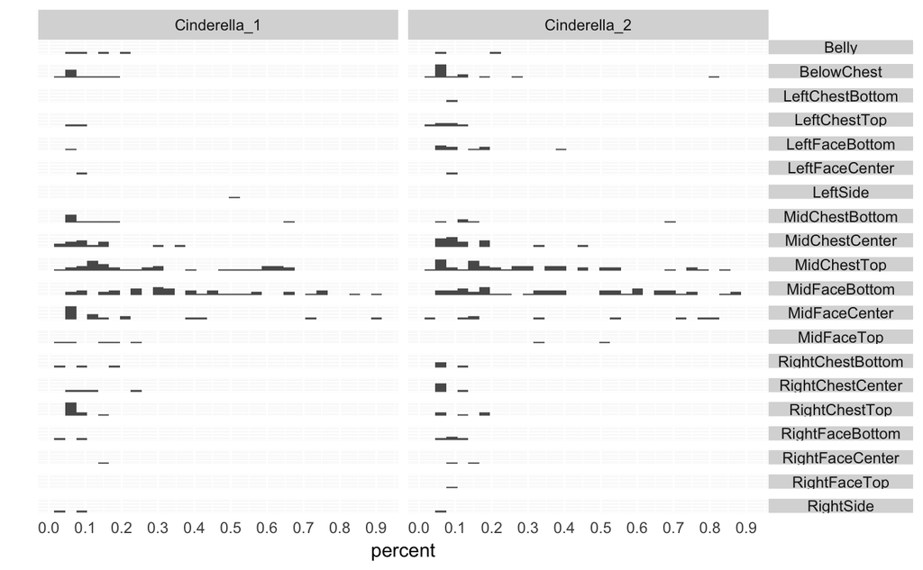

```r
# Pull apart condition and AOI columns
data <- data %>%
  separate(condition, into = c("story", "clipnum", "direction", "media"), sep = "_") %>%
  unite(story, clipnum, col = "story", sep = "_") %>%
  select(-media) %>%
  separate(aoi, into = c("math", "label", "aoi", "hitlabel", "indicator"), sep = "_") %>%
  select(-math, -label, -hitlabel, -indicator)
# Remove numbers from end of AOI label
data <- data %>%
  mutate(aoi = case_when(
    str_detect(aoi, "\\d") ~ str_sub(aoi, 0, -2),
    TRUE ~ aoi
  ))
# Now let's add cliplengths again, but this time to data, and calculate percentage looking times
data <- data %>%
  left_join(cliplength, by = "story") %>%
  select(-frames) %>%
  mutate(secs = hits/120,
         percent = secs/clip_sec)
# Histogram!
data_ci <- data %>% filter(str_detect(story, "Cinderella"), percent > 0.04)
data_km <- data %>% filter(str_detect(story, "KingMidas"), percent > 0.04)
data_3b <- data %>% filter(str_detect(story, "ThreeBears"), percent > 0.04)
data_rr <- data %>% filter(str_detect(story, "RedRiding"), percent > 0.04)
ggplot(data_ci, aes(x = percent)) + geom_histogram() + facet_grid(aoi ~ story) + theme(strip.text.y = element_text(angle = 0), axis.text.y = element_blank(), axis.ticks = element_blank()) + ylab("") +
  scale_x_continuous(breaks=seq(0, 1, .1))
```

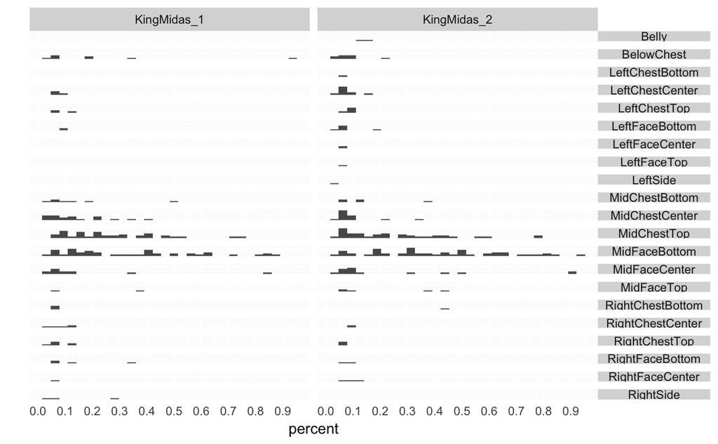

```r
ggplot(data_km, aes(x = percent)) + geom_histogram() + facet_grid(aoi ~ story) + theme(strip.text.y = element_text(angle = 0), axis.text.y = element_blank(), axis.ticks = element_blank()) + ylab("") +
  scale_x_continuous(breaks=seq(0, 1, .1))
```

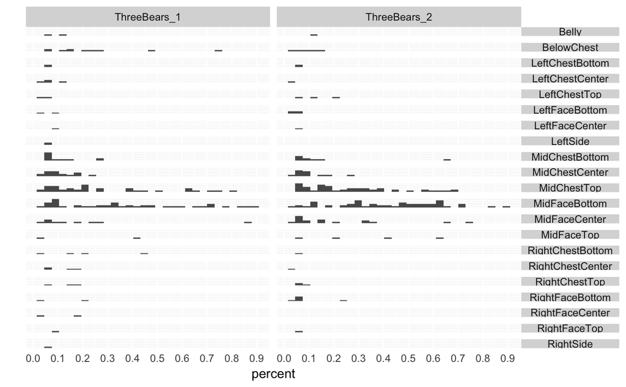

```r
ggplot(data_3b, aes(x = percent)) + geom_histogram() + facet_grid(aoi ~ story) + theme(strip.text.y = element_text(angle = 0), axis.text.y = element_blank(), axis.ticks = element_blank()) + ylab("") +
  scale_x_continuous(breaks=seq(0, 1, .1))
```

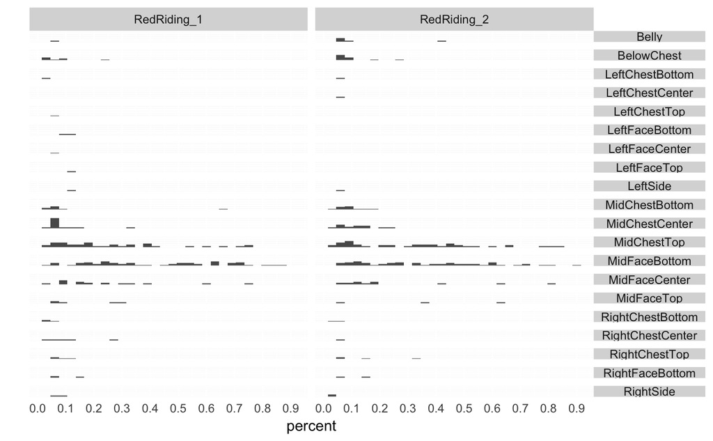

```r
ggplot(data_rr, aes(x = percent)) + geom_histogram() + facet_grid(aoi ~ story) + theme(strip.text.y = element_text(angle = 0), axis.text.y = element_blank(), axis.ticks = element_blank()) + ylab("") +
  scale_x_continuous(breaks=seq(0, 1, .1))
```

Based on these histograms, I sent to Rain on 26 Oct 2017 this table. Plus I asked about Jelena (CODA) who had very little data in 14 out of 16 trials so she was thrown out entirely from the dataset. I wrote to Rain:

> Alright, here’s what I found. Good news, I’m not seeing any really BAD kids! Yay. Just two that may need to be looked at. Attached is the list of all kids/stories I flagged for having way too much looking in that AOI. The trial column indicates which clip out of 16 (so 5 means 5th clip in the sequence). Most kids on the list are fine really, I think, and, yes, these AOIs were flagged for having weirdly high percentages but what probably happened was that they zoned out during that particular clip or stared at something interesting/idiosyncratic. I would especially review the static gaze plot/scatterplot images for these kids:

> Lyla (Group 1) - A lot of chest looking. Calibration may have been shifted down.

> Mason (Group 2) - VERY focused on MidFaceCenter across several stories (that’s usually a low AOI). It could be that his calibration is shifted up; all other kids look at MidFaceBottom, not MidFaceCenter). Or it could just be his idiosyncratic looking behavior. Give it a look.

```r
outliers <- read_csv("outliers.csv") %>%
  separate(outlier, into = letters[seq( from = 1, to = 9 )]) %>%
  select(-a, -c, -h) %>%
  rename(participant = b,
         group = d,
         trial = g,
         aoi = i) %>%
  unite(col = "story", e:f, sep = "_") %>%
  select(group, participant, story, trial, aoi) %>%
  arrange(group, participant)
outliers
```

| group | participant | story | trial | aoi |
| --- | --- | --- | --- | --- |
| 1 | Ainsely | Cinderella_2 | 9 | leftchestbottom |
| 1 | Ainsely | KingMidas_1 | 15 | midchestbottom |
| 1 | Ainsely | RedRiding_1 | 10 | belly |
| 1 | al10pa24 | Cinderella_1 | 15 | belowchest |
| 1 | Annika | ThreeBears_1 | 6 | rightchestbottom |
| 1 | dylan | Cinderella_2 | 1 | midfacecenter |
| 1 | Isiah | Cinderella_1 | 5 | leftside |
| 1 | Isiah | Cinderella_1 | 5 | rightchestcenter |
| 1 | Isiah | KingMidas_2 | 4 | belly |
| 1 | Isiah | ThreeBears_1 | 14 | belly |

[output cut: 27 more lines]

```r
write_csv(outliers, "outlierkids.csv")
```

# Save!

Great. Let’s save this as `cleanedchildeyedata.csv’.

```r
# A bit more cleaning up
data <- data %>%
  mutate(direction = case_when(
    direction == "FW" ~ "forward",
    direction == "ER" ~ "reversed"
  )) %>%
  mutate(language = case_when(
    language == "SignLanguageExposed" ~ "sign",
    language == "EnglishExposed" ~ "english"
  )) %>%
  mutate(group = as.factor(group),
         gender = as.factor(gender),
         language = as.factor(language),
         story = as.factor(story),
         direction = as.factor(direction),
         aoi = as.factor(aoi))
# Save as csv and feather (feather preserves column types for R)
write_csv(data,"cleanedchildeyedata.csv")
write_feather(data,"cleanedchildeyedata.feather")
```

# Participant Table

Now we can present the following table about our participants.

```r
participants <- data %>%
  select(participant, gender, language, age) %>%
  distinct()
participants_n <- participants %>%
  count(gender, language) %>%
  spread(gender, n)
participants_age <- participants %>%
  group_by(language) %>%
  summarise(age_m = round(mean(age), 1),
            age_sd = round(sd(age), 1),
            age_min = range(age)[1],
            age_max = range(age)[2]) %>%
  mutate(age_range = paste(age_min, age_max, sep = " - ")) %>%
  select(-age_min, -age_max) %>%
  mutate(age_mean = paste(age_m, age_sd, sep = "±")) %>%
  select(-age_m, -age_sd) %>%
  select(language, age_mean, age_range)
left_join(participants_n, participants_age, by = "language")
```

| language | Female | Male | age_mean | age_range |
| --- | --- | --- | --- | --- |
| english | 8 | 7 | 5±1.4 | 2.7 - 8.3 |
| sign | 10 | 11 | 5.2±2.1 | 2.13 - 10.5 |